# Homework 2

### 4. Make a scatterplot of *hwy* vs *cyl*.

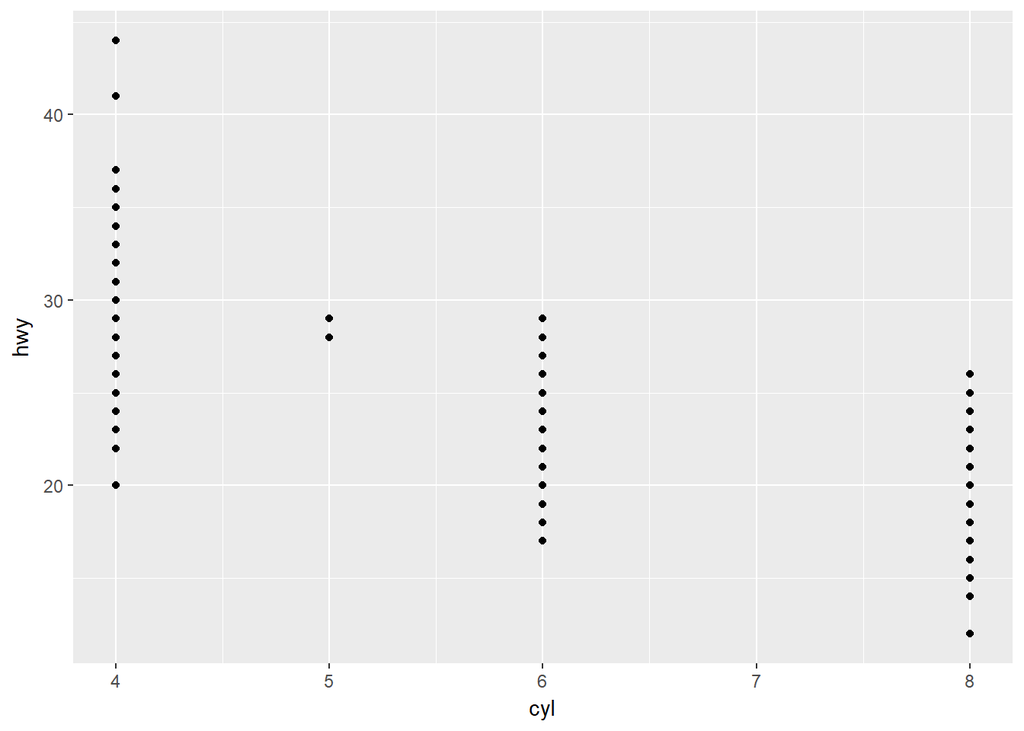

```r
ggplot(data = mpg) + geom_point(mapping = aes(x = cyl, y = hwy))
```

### 5. What happens if you make a scatterplot of *class* versus *drv*. Why is the plot not useful?

This graph is not useful since the drive type is simply a feature of each drive class. There is no correlation in observations here to derive any useful insight from.

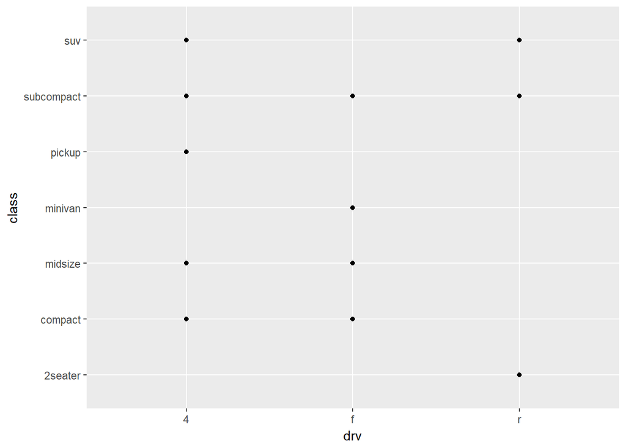

```r
ggplot(data = mpg) + geom_point(mapping = aes(x = drv, y = class))
```

## 3.3.1 Exercises

The string “blue” is set inside of the aes() function. To manually assign “blue”, the color should be set as an argument of the geom function.

### 2. Which variables in mpg are categorical? Which variables are continuous?

Categorical - fuel type, class, drive type, transmission type, model, year Continuous - highway miles per gallon, city miles per gallon, engine displacement

You can display the dataframe values and help file to tell which variables are “types” and which are sets of continuous values.

### 3. Map a continuous variable to color, size, and shape. How do these aesthetics behave differently for categorical vs. continuous variables?

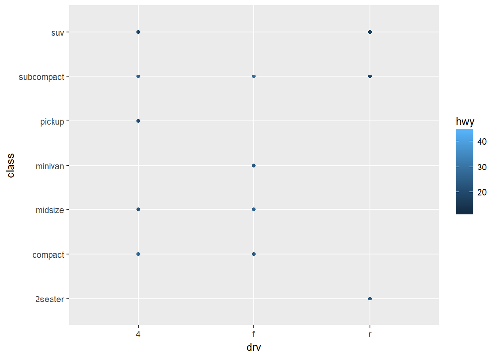

```r
ggplot(data = mpg) + geom_point(mapping = aes(x = drv, y = class, color=hwy))
```

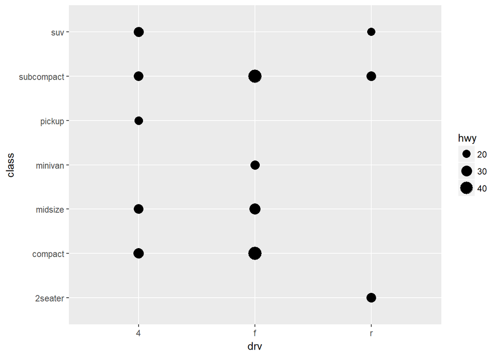

```r
ggplot(data = mpg) + geom_point(mapping = aes(x = drv, y = class, size=hwy))
```

For a continuous variable, the color and shape is a spectrum and is harder to distinguish and get meaning from. For a shape, a continuous variable is not allowed.

### 4. What happens if you map the same variable to multiple aesthetics?

You can assign multiple aesthetics to transmission type.

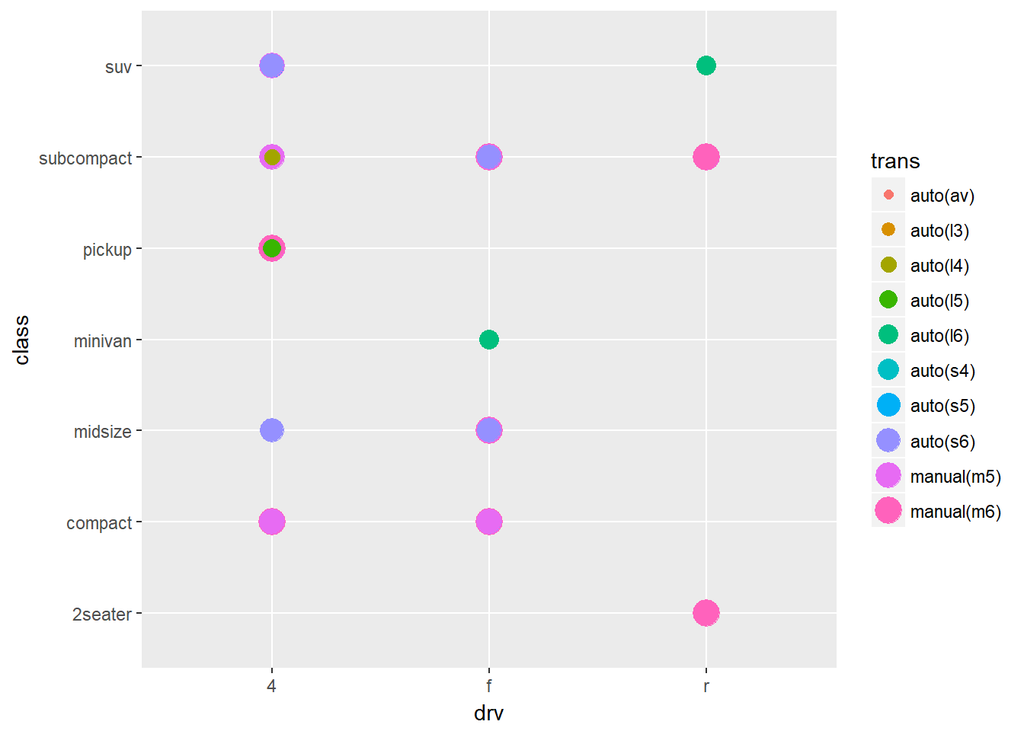

```r
ggplot(data = mpg) + geom_point(mapping = aes(x = drv, y = class, size=trans, color=trans))
```

5. What does the stroke aesthetic do? What shapes does it work with? (Hint: use ?geom_point)

The stroke aesthetic controls the thickness of shapes that have a border.

6. What happens if you map an aesthetic to something other than a variable name, like aes(colour = displ < 5)?

This will split the colors based on the expressions value. So in the case of a boolean expression, it would split the dataset into two colors.

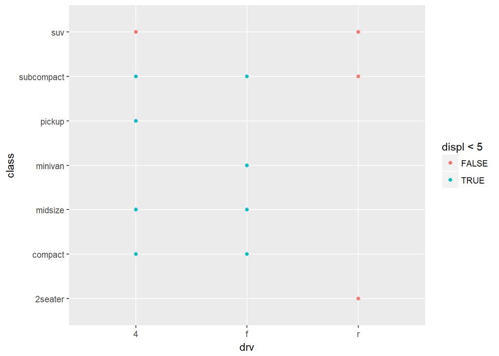

```r
ggplot(data = mpg) + geom_point(mapping = aes(x = drv, y = class, color=displ < 5))
```

## Exercises 3.5.1

### 4. Take the first faceted plot in this section:

What are the advantages to using faceting instead of the colour aesthetic? What are the disadvantages? How might the balance change if you had a larger dataset?

Facetting allows you to see the points for a particular variable on its own subplot. This can make it easier to see values that may overlap. In a larger dataset, this would be more valuable if there are many values close together.

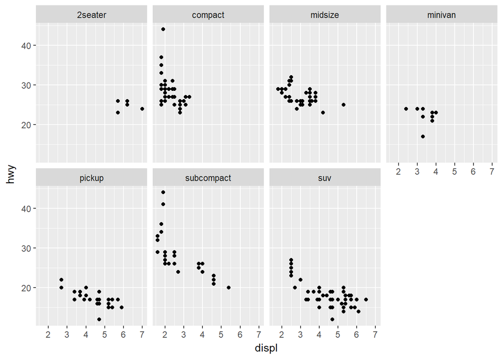

```r
ggplot(data = mpg) +
  geom_point(mapping = aes(x = displ, y = hwy)) +
  facet_wrap(~ class, nrow = 2)
```

### 5. Read ?facet_wrap. What does nrow do? What does ncol do? What other options control the layout of the individual panels? Why doesn’t facet_grid() have nrow and ncol argument?

nrow and ncol specify the number of rows and the number of columns respectively. facet_grid rows and columns are defined by two discrete facetting variables.

```r
?facet_wrap
```

## 3.6.1 Exercises

### 1. What geom would you use to draw a line chart? A boxplot? A histogram? An area chart?

You can use geom_smooth() to draw a line chart, geom_boxplot() to draw a boxplot, geom_bar to draw a histogram, and geom_area() to draw an area chart.

### 2. Run this code in your head and predict what the output will look like. Then, run the code in R and check your predictions.

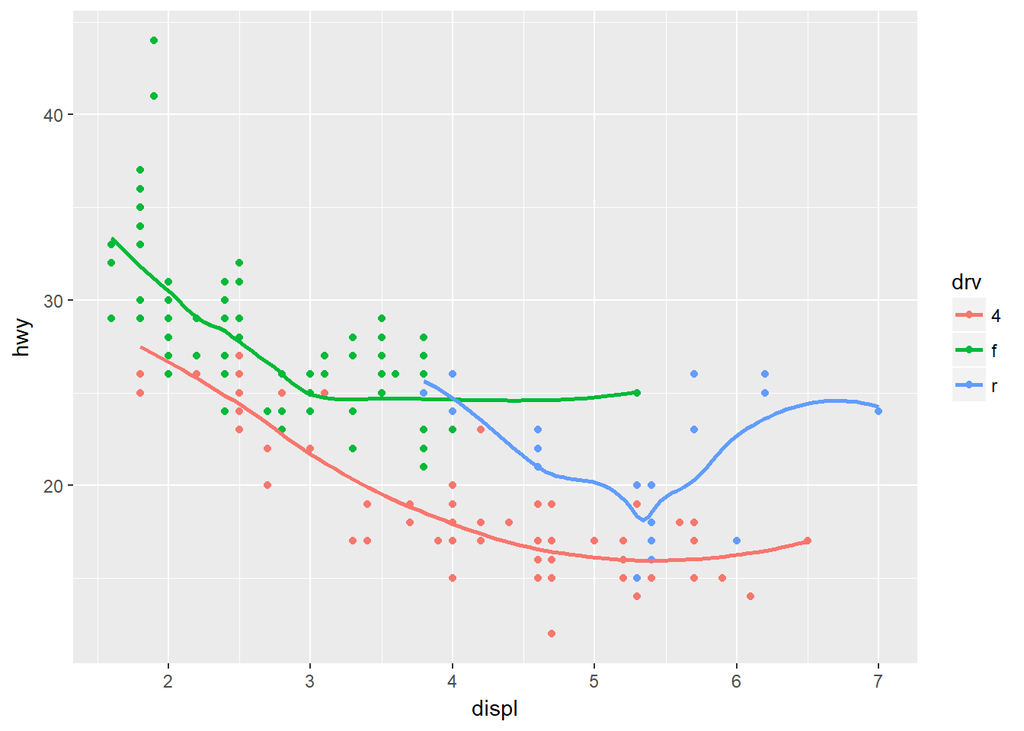

```r
ggplot(data = mpg, mapping = aes(x = displ, y = hwy, color = drv)) +
  geom_point() +
  geom_smooth(se = FALSE)
```

### 3. What does show.legend = FALSE do? What happens if you remove it?

Why do you think I used it earlier in the chapter?

show.legend = FALSE will hide the legend. By default, a legend is added. The legend provides additional context as to what colors or shapes mean.

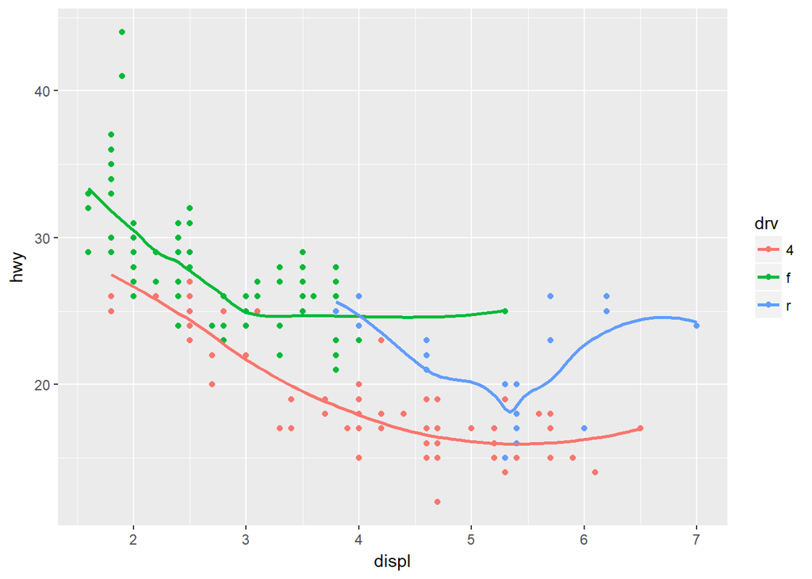

```r
ggplot(data = mpg, mapping = aes(x = displ, y = hwy, color = drv)) +
  geom_point() +
  geom_smooth(se = FALSE)
```

### 4. What does the se argument to geom_smooth() do?

The *se* argument displays the confidence interval around the line.

### 5. Will these two graphs look different? Why/why not?

They look the same because both geometries use the same aesthetic, they are just defined in different places.

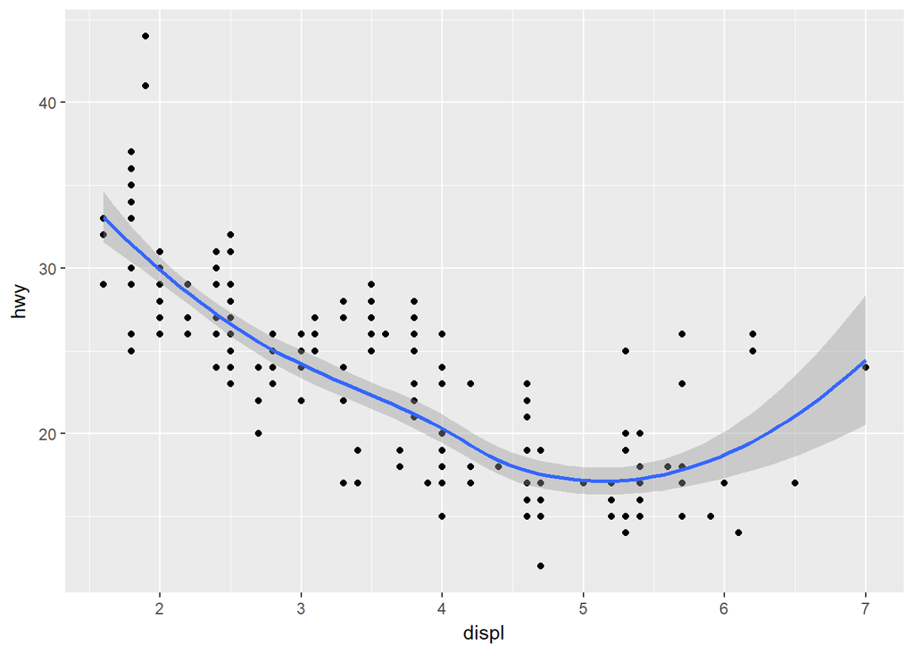

```r
ggplot(data = mpg, mapping = aes(x = displ, y = hwy)) +
  geom_point() +
  geom_smooth()
```

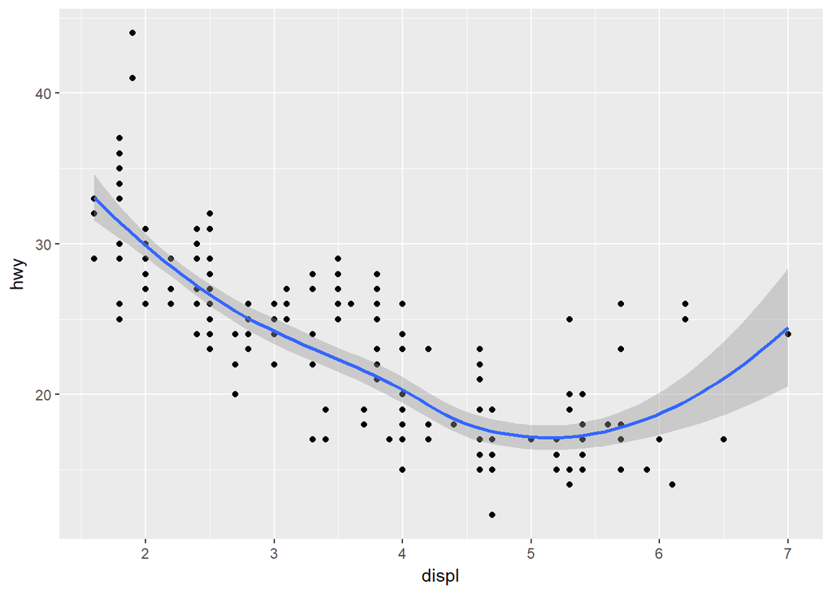

```r
ggplot() +
  geom_point(data = mpg, mapping = aes(x = displ, y = hwy)) +
  geom_smooth(data = mpg, mapping = aes(x = displ, y = hwy))
```